# Heart Disease in Cleveland

**A proposal by Group 20 DSCI 100 007** Phoebe McNair-Luxon, Alexandre Beauchemin, Kumaravendhan Ravichandran, Evi Dorsch

Data set source: https://archive.ics.uci.edu/ml/datasets/Heart+Disease

# Introduction

Coronary artery disease (CAD) is a disease of the heart in which patients are at high risk for a heart attack. CAD is caused by buildup in the walls of the arteries such as cholesterol, over time this can lead to a blockage partially blocking the blood flow (Centers for Disease Control and Prevention, 2021; Cleveland Clinic, 2022). In this study, we will be using a mixture of census data and medical data to predict the diagnosis of CAD.

The question that we are answering with this dataset is; Is it possible to accurately predict CAD from only census data, or only medical data? Is it more accurate to combine both data types in a single model?

To perform this analysis, we will be using the Cleveland Clinic Data of the Heart Disease Data. This data set looks at 303 patients diagnosed with CAD via an invasive angiogram and the results of noninvasive clinical tests which could indicate CAD (Detrano et al., 1989).

```r
library(tidyverse)
library(tidymodels)
library(repr)
library(gridExtra)
library(readxl)
set.seed(4200)
```

```
• Use tidymodels_prefer() to resolve common conflicts.
```

## Preliminary Exploratory Data Analysis

```r
# read in data
Cl_heart_data <- read.table("https://archive.ics.uci.edu/ml/machine-learning-databases/heart-disease/processed.cleveland.data", sep = ",",
                 col.names = c("age", "sex", "cp", "trestbps", "chol", "fbs",  "restecg", "thalach", "exang", "oldpeak", "slope", "ca", "thal", "num"))


#select for columns
clean_heart_data <- Cl_heart_data |>
    select("age", "sex", "trestbps", "chol", "fbs", "oldpeak", "num")


#splitting data into training and testing sets
heart_data_split <-  initial_split(clean_heart_data, prop = 0.75, strata = num)
heart_train <- training(heart_data_split) |>
    select(-num)
heart_test <- testing(heart_data_split)
# head(heart_train)
# head(heart_test)

# visualizing the data (only training data)
names <- c("Mean", "Median")
mean <- heart_train |>
    map_df(mean, na.rm = TRUE)
median <- heart_train |>
    map_df(median, na.rm = TRUE)
tbl1 <- bind_rows(mean, median)# , count)
exploratory_analysis <- bind_cols(names, tbl1)
exploratory_analysis

number_of_rows <- heart_train |>
    nrow()
number_of_rows
```

A tibble: 2 × 7

| ...1 <chr> | age <dbl> | sex <dbl> | trestbps <dbl> | chol <dbl> | fbs <dbl> | oldpeak <dbl> |
| --- | --- | --- | --- | --- | --- | --- |
| Mean | 54.72444 | 0.68 | 132.3822 | 247.6489 | 0.1377778 | 1.075111 |
| Median | 56.00000 | 1.00 | 130.0000 | 244.0000 | 0.0000000 | 0.800000 |

225

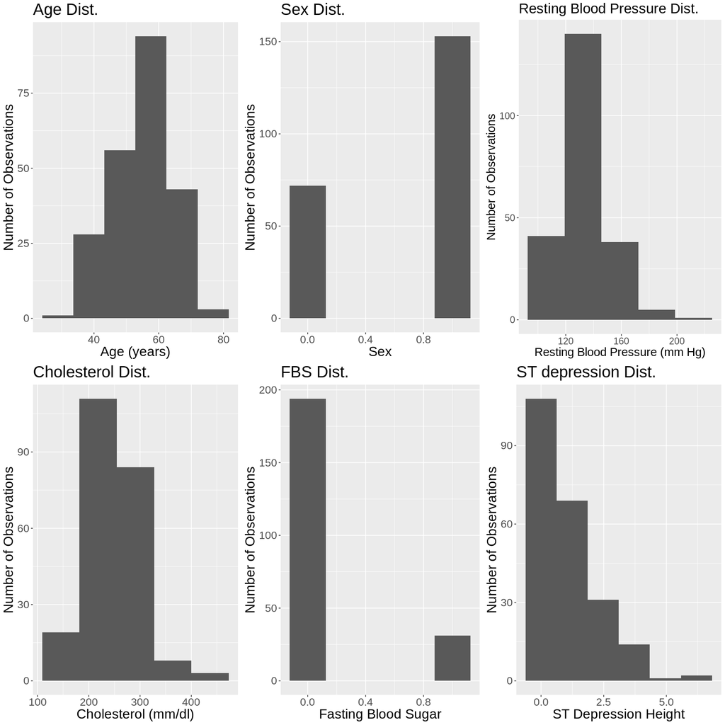

```r
options(repr.plot.height = 15, repr.plot.width = 15)

# Visulize data distribution in a graph
age_distribution <- heart_train |>
    ggplot() +
    geom_histogram(bins = 6, aes(x=age)) +
    labs(x="Age (years)",y = "Number of Observations") +
    ggtitle("Age Dist.") +
    theme(text=element_text(size=20))

sex_distribution <- heart_train |>
    ggplot() +
    geom_histogram(bins = 5, aes(x=sex)) +
    labs(x="Sex",y = "Number of Observations") +
    ggtitle("Sex Dist.") +
    theme(text=element_text(size=20))

trestbps_distribution <- heart_train |>
    ggplot() +
    geom_histogram(bins = 5,aes(x=trestbps)) +
    labs(x="Resting Blood Pressure (mm Hg)",y = "Number of Observations") +
    ggtitle("Resting Blood Pressure Dist.") +
    theme(text=element_text(size=17.5))

chol_distribution <- heart_train |>
    ggplot() +
    geom_histogram(bins = 5,aes(x=chol)) +
    labs(x="Cholesterol (mm/dl)",y = "Number of Observations") +
    ggtitle("Cholesterol Dist.")+
    theme(text=element_text(size=20))

fbs_distribution <- heart_train |>
    ggplot() +
    geom_histogram(bins = 5 ,aes(x=fbs)) +
    labs(x="Fasting Blood Sugar",y = "Number of Observations") +
    ggtitle("FBS Dist.") +
    theme(text=element_text(size=20))

oldpeak_distribution <- heart_train |>
    ggplot() +
    geom_histogram(bins = 6,aes(x=oldpeak)) +
    labs(x="ST Depression Height",y = "Number of Observations") +
    ggtitle("ST depression Dist.") +
    theme(text=element_text(size=20))


grid.arrange(age_distribution,sex_distribution,trestbps_distribution, chol_distribution, fbs_distribution, oldpeak_distribution, ncol =3)
```

# Methods

The columns to be used in our analysis are as follows: for census data, sex and age; for medical data, resting blood pressure (trestbps), cholesterol level (chol), fasting blood sugar (fbs) and ST depression (oldpeak). The state of diagnosis (num) will be used.

We will build three classification models: the first using census data; the second, medical data; and the third, both. We will then evaluate the accuracy of all three models and compare metrics, determining which set of variables results in the best prediction accuracy.

We will be using the K-nearest neighbors classification algorithm to predict observations from our training set. We will complete each of the 3 models by following these steps.

1. Randomly divide the data into training and test data sets to find the best K value, utilizing the training set to create the classifier and the test set to evaluate its accuracy. We will tune the classifier by optimizing estimated accuracy using cross-validation.
2. Create a model specification for K-nearest neighbors, specifying the number of neighbors.
3. Create a centering/scaling recipe using the recipe function and specify target and predictor variables.
4. Pass the model specification and recipe under a workflow, specifying the data to run on.
5. Make a prediction for the new observation using predict function by passing the fit object and the new observation into it.
6. Collect the metrics of our predictions, specifying the accuracy.

**Data Visualization:** We intend to plot a bar graph with accuracy data for each model on the y-axis to visualize whether it is more accurate to look at census data, medical data, or both

# Expected Outcomes and Significance

Existing literature shows a positive relationship between CAD and age (Brown et al., 2022), resting blood pressure (Cleveland Clinic, 2021), cholesterol level (Centers for Disease Control and Prevention, 2021), fasting blood sugar (American Heart Association Inc., 2021), ST depression (Klabunde, 2023); and the male sex (Gheisari, 2020). The expected outcome of this classification analysis is that census data will not be sufficient to predict CAD, whereas medical data will be. The combined model will be most accurate in CAD prediction.

The findings from this analysis could be insightful into how medical data and census data could be used to provide accurate prediction models for CAD risk across a general population. If the demographic predictors are sufficient to predict CAD, diagnosis could be more accessible.

This classification analysis could lead to further questioning on how CAD diagnosis could require less medically-invasive tests by using only demographic and data of personal history.

# References

American Heart Association, Inc. (2021, May 4). Cardiovascular Disease and Diabetes. https://www.heart.org/en/health-topics/diabetes/diabetes-complications-and-risks/cardiovascular-disease--diabetes

Brown, J., Gerhandt, T., & Kwon, E. (2022). Risk Factors For Coronary Artery Disease. StatPearls Publishing.

Cleveland Clinic. (2022, August 18). Coronary Artery Disease. https://my.clevelandclinic.org/health/diseases/16898-coronary-artery-disease

Cleave Clinic. (2021, September 21). High Blood Pressure (Hypertension). https://my.clevelandclinic.org/health/diseases/4314-hypertension-high-blood-pressure

Centers for Disease Control and Prevention. (2021, July 19). Coronary Artery Disease. https://www.cdc.gov/heartdisease/coronary_ad.htm

Centers for Disease Control and Prevention. (2022, June 20). Heart Disease. https://www.cdc.gov/diabetes/library/features/diabetes-and-heart.html

Detrano, R., Janosi, A., Steinbrunn, W., Pfisterer, M., Schmid, J.J., Sandhu., Guppy, K.H., Lee, S., & Froelicher, V. (1989). International application of a new probability algorithm for the diagnosis of coronary artery disease. Am J Cardiol, 64 (5), 304-310. https://doi.org/10.1016/0002-9149(89)90524-9

Gheisari, F., Emami, M., Shahraki, H.R., Samipour, S., & Nematollahi, P. (2020). The Role of Gender in the Importance of Risk Factors for Coronary Artery Disease. Cardiol Res Pract, Article 6527820. https://doi.org/10.1155/2020/6527820

Klabunde, R. (2023, January 30). Electrophysiological Changes During Cardiac Ischemia. Cardiac Physiology Concepts. https://www.cvphysiology.com/CAD/CAD012